# Set Up

Thanks for your interest in learning R. For the CERF R workshop, we will be using [RStudio](https://www.rstudio.com/) as our interface to R. In order to participate in this workshop you will need to make sure you have R and RStudio installed on your laptop. Big thanks to the [USGS-R Training group](https://owi.usgs.gov/R/training.html) for making their installation materials availabe. The instructions below are mostly theirs with some light editing and should help you get all set up for the workshop.

# Workshop Location

Room 553AB, fifth floor of the Rhode Island Convention Center. See the conference [web app](https://cerf.confex.com/cerf/2017/meetingapp.cgi/Index/Workshops~1).

# Install R and RStudio

These instructions are for Windows install. Download and install R for Mac [here](https://cran.r-project.org/bin/macosx/).

## Download and install R

Go to [CRAN and download](https://cran.rstudio.com/bin/windows/base/) the R installer for Windows. Make sure to choose the latest stable version (v3.4.2 as of October 2017).

Once the installer downloads, Right-click on it and select “Run as administrator”.

Type in your credentials and click yes (or if you don’t have administrator access have your IT rep install with Admin privileges).

[figure not shown]

Run as admin

[figure not shown]

Install Destination screen

At the “Select Components” screen, you can accept the default and install both 32-bit and 64-bit versions.

[figure not shown]

Select Architecture

At this screen, uncheck ‘Create a desktop icon’ because non-admin users in Windows will be unable to delete it.

[figure not shown]

Uncheck desktop icon

## Download and install RStudio

[Download RStudio Desktop](https://www.rstudio.com/products/rstudio/download/)

Double-click the installer. It will ask for your administrator credentials to install (you might need to have your IT rep install again).

Accept all the default options for the RStudio install.

[figure not shown]

RStudio install screen

# Check Install

## Open RStudio

Once installed, RStudio should be accessible from the start menu. Start up RStudio. Once running it should look something like:

[figure not shown]

RStudio Window

## Find “Console” window

By default the console window will be on the left side of RStudio. Find that window. It will looking something like:

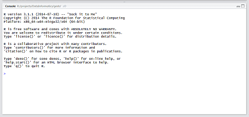

RStudio Console

## Copy and paste the code

Click in the window and paste in the code from below:

```r
version$version.string
```

## Verify your installed R version

Ideally you should be running the latest stable release (v3.4.2 as of October 2017). If you have an older version, please install the newest version using the instructions above.

Here is what my R version looks like.

```
## [1] "R version 3.4.1 (2017-06-30)"
```

# Add packages

## Install general packages

Install packages available for all R users from [CRAN](https://cran.r-project.org/) by pasting the following code and hitting `ENTER`.

```r
install.packages(c("dplyr","ggplot2","tidyr"))
```

If you see

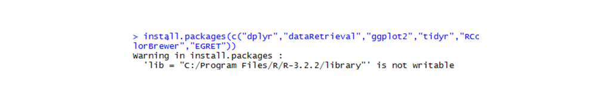

Dialog box behind

That’s OK! There’s a dialog box hiding behind RStudio asking if you want to create a personal folder in your Documents folder. Click *Yes*. It will look something like this when done:

[figure not shown]

Console output

## Install geospatial and time series packages

If you are taking the afternoon workshops as well, please also run the following to install the required packages.

```r
#spatial packages
install.packages(c("sf","rgdal","sp","raster"))

#time series packages
install.packages(c("lubridate", "EnvStats"))
```

## Exercise 1

Just to make sure everything is working do the following:

1. Open up RStudio.
2. Find the “Console.” This is usually the left part RStudio.
3. In the “Console”, find the R Prompt.
4. Type in (copy and paste from here will also work) the following commands at the R Prompt and hit return.

```r
"dplyr" %in% installed.packages()
"ggplot2" %in% installed.packages()
```

The end result should look something like:

[figure not shown]